# transitiontrees::bootstrap_pathways() — demonstration

2026-06-07

## What `bootstrap_pathways()` reports

Methodologically built on Saqr, Tikka & López-Pernas (2025) (doi:10.1145/3706468.3706513), extending an edge-level bootstrap framework to variable-depth pathways.

The bootstrap operates on **raw counts only** — no `nmin` filter, no smoothing inside the loop, no extra parameters. Each iteration resamples whole sequences, aggregates counts per depth, and reads each original-tree pathway’s count vector directly.

## Validation: strong, weak, random

Three Markov regimes from a small inline first-order Markov generator, same sample size (100 sequences × 14 length, alphabet `{A, B, C}`):

```r
P_strong <- rbind(c(0.05, 0.90, 0.05),
                  c(0.05, 0.05, 0.90),
                  c(0.90, 0.05, 0.05))
P_weak   <- rbind(c(0.30, 0.50, 0.20),
                  c(0.20, 0.30, 0.50),
                  c(0.50, 0.20, 0.30))
P_random <- matrix(1 / 3, 3L, 3L)
rownames(P_strong) <- colnames(P_strong) <- c("A", "B", "C")
rownames(P_weak)   <- colnames(P_weak)   <- c("A", "B", "C")
rownames(P_random) <- colnames(P_random) <- c("A", "B", "C")
init <- c(A = 1/3, B = 1/3, C = 1/3)

# Inline first-order Markov sequence generator: returns a
# character matrix (n_sequences rows × seq_length columns).
simulate_markov <- function(n_sequences, seq_length, trans_matrix,
                            init_probs, seed) {
  set.seed(seed)
  states <- colnames(trans_matrix)
  step <- function(prev, ignore) {
    sample(states, 1L, prob = trans_matrix[prev, ])
  }
  one_seq <- function(i) {
    first <- sample(states, 1L, prob = init_probs)
    Reduce(step, seq_len(seq_length - 1L), accumulate = TRUE,
           init = first)
  }
  do.call(rbind, lapply(seq_len(n_sequences), one_seq))
}

run_scenario <- function(P, seed) {
  seqs <- simulate_markov(
    n_sequences = 100L, seq_length = 14L,
    trans_matrix = P, init_probs = init, seed = seed)
  tree <- context_tree(seqs, max_depth = 2L, min_count = 5L)
  bootstrap_pathways(tree, iter = 300L, seed = 1L)
}

b_strong <- run_scenario(P_strong, seed = 1L)
b_weak   <- run_scenario(P_weak,   seed = 2L)
b_random <- run_scenario(P_random, seed = 3L)
```

### Print: STRONG (modal probability 0.90)

```r
b_strong
```

```
## <transitiontrees_bootstrap>  300 resamples
##   stability  : count in [0.50, 1.50] x observed, p < 0.05
##   informative: G^2 > qchisq(0.95, df=k-1) = 5.99, threshold 0.80
##   pathways   : 13 total, 13 stable, 3 informative, 3 both
##
## top pathways (stable + informative first):
##  pathway depth count p_stability stability_rate stable informative_rate
##        C     1   438       0.003          1.000   TRUE            1.000
##        A     1   436       0.003          1.000   TRUE            1.000
##        B     1   426       0.003          1.000   TRUE            1.000
##  (start)     0  1400       0.003          1.000   TRUE               NA
##   C -> A     2   368       0.003          1.000   TRUE            0.000
##   B -> C     2   352       0.003          1.000   TRUE            0.000
##   A -> B     2   348       0.003          1.000   TRUE            0.003
##   A -> C     2    27       0.007          0.997   TRUE            0.177
##   B -> B     2    25       0.017          0.987   TRUE            0.257
##   A -> A     2    18       0.020          0.983   TRUE            0.037
##  informative mean_G2 ci_G2_lo ci_G2_hi
##         TRUE 610.320  550.600  677.821
##         TRUE 590.714  545.239  637.437
##         TRUE 583.347  536.553  633.219
##        FALSE     NaN       NA       NA
##        FALSE   0.543    0.014    1.808
##        FALSE   0.641    0.046    1.970
##        FALSE   0.769    0.032    2.572
##        FALSE   4.448    2.121    8.050
##        FALSE   5.026    2.016   10.833
##        FALSE   3.606    2.038    6.217
## # ... 3 more pathways (use summary(x) for full table)
```

Three depth-1 pathways (A, B, C) have G² ~600 with tight CIs — their conditional distribution differs dramatically from the marginal, so `informative_rate = 1`. Depth-2 pathways have G² near zero because the data is 1st-order Markov: conditional on the most recent state, prior history adds nothing. The bootstrap correctly flags depth-1 as informative and depth-2 as not — the latter would be the wrong choice in a longer-memory tree.

### Print: WEAK (modal probability 0.50)

```r
b_weak
```

```
## <transitiontrees_bootstrap>  300 resamples
##   stability  : count in [0.50, 1.50] x observed, p < 0.05
##   informative: G^2 > qchisq(0.95, df=k-1) = 5.99, threshold 0.80
##   pathways   : 13 total, 13 stable, 3 informative, 3 both
##
## top pathways (stable + informative first):
##  pathway depth count p_stability stability_rate stable informative_rate
##        B     1   455       0.003              1   TRUE            1.000
##        A     1   434       0.003              1   TRUE            1.000
##        C     1   411       0.003              1   TRUE            1.000
##  (start)     0  1400       0.003              1   TRUE               NA
##   A -> B     2   211       0.003              1   TRUE            0.000
##   B -> C     2   208       0.003              1   TRUE            0.023
##   C -> A     2   182       0.003              1   TRUE            0.033
##   B -> B     2   116       0.003              1   TRUE            0.097
##   A -> A     2   114       0.003              1   TRUE            0.180
##   B -> A     2   103       0.003              1   TRUE            0.033
##  informative mean_G2 ci_G2_lo ci_G2_hi
##         TRUE  59.077   35.472   82.717
##         TRUE  61.262   38.464   86.434
##         TRUE  51.363   28.872   77.407
##        FALSE     NaN       NA       NA
##        FALSE   1.134    0.030    3.884
##        FALSE   1.978    0.100    5.802
##        FALSE   1.867    0.041    6.364
##        FALSE   2.629    0.090    8.778
##        FALSE   3.624    0.165   10.705
##        FALSE   1.709    0.066    6.440
## # ... 3 more pathways (use summary(x) for full table)
```

Same structure, weaker signal. Depth-1 G² ~50–60: still well above the chi-square critical value (5.99), so depth-1 is reproducibly informative. Depth-2 G² ~1–4 sits below the critical value most of the time, so depth-2 is reproducibly not informative — exactly right for 1st-order Markov.

### Print: RANDOM (uniform 1/3)

```r
b_random
```

```
## <transitiontrees_bootstrap>  300 resamples
##   stability  : count in [0.50, 1.50] x observed, p < 0.05
##   informative: G^2 > qchisq(0.95, df=k-1) = 5.99, threshold 0.80
##   pathways   : 13 total, 13 stable, 2 informative, 2 both
##
## top pathways (stable + informative first):
##  pathway depth count p_stability stability_rate stable informative_rate
##        C     1   446       0.003              1   TRUE            0.860
##        A     1   425       0.003              1   TRUE            0.923
##  (start)     0  1400       0.003              1   TRUE               NA
##        B     1   429       0.003              1   TRUE            0.453
##   A -> A     2   159       0.003              1   TRUE            0.047
##   C -> C     2   158       0.003              1   TRUE            0.110
##   C -> B     2   153       0.003              1   TRUE            0.010
##   B -> B     2   142       0.003              1   TRUE            0.047
##   A -> C     2   131       0.003              1   TRUE            0.003
##   B -> A     2   127       0.003              1   TRUE            0.123
##  informative mean_G2 ci_G2_lo ci_G2_hi
##         TRUE  12.432    3.130   25.564
##         TRUE  13.959    4.512   27.035
##        FALSE     NaN       NA       NA
##        FALSE   5.913    0.703   15.208
##        FALSE   1.951    0.061    6.614
##        FALSE   2.444    0.063    9.202
##        FALSE   1.453    0.036    4.876
##        FALSE   1.812    0.043    7.192
##        FALSE   1.673    0.042    5.167
##        FALSE   2.973    0.138    8.837
## # ... 3 more pathways (use summary(x) for full table)
```

### Headline numbers across regimes

```r
cmp <- function(b, label) {
  s <- b$summary
  data.frame(
    scenario      = label,
    n_pathways    = nrow(s),
    n_stable      = sum(s$stable, na.rm = TRUE),
    n_informative = sum(s$informative, na.rm = TRUE),
    n_both        = sum(s$stable & s$informative, na.rm = TRUE),
    median_G2     = round(median(s$mean_G2, na.rm = TRUE), 2),
    mean_G2       = round(mean(s$mean_G2, na.rm = TRUE), 2),
    p95_G2        = round(quantile(s$mean_G2, 0.95,
                                    na.rm = TRUE), 2)
  )
}
rbind(
  cmp(b_strong, "STRONG (modal=0.90)"),
  cmp(b_weak,   "WEAK   (modal=0.50)"),
  cmp(b_random, "RANDOM (uniform)")
)
```

|  | scenario | n_pathways | n_stable | n_informative | n_both | median_G2 | mean_G2 | p95_G2 |
| --- | --- | --- | --- | --- | --- | --- | --- | --- |
| 95% | STRONG (modal=0.90) | 13 | 13 | 3 | 3 | 4.03 | 151.04 | 599.54 |
| 95%1 | WEAK (modal=0.50) | 13 | 13 | 3 | 3 | 2.30 | 15.97 | 60.06 |
| 95%2 | RANDOM (uniform) | 13 | 13 | 2 | 2 | 2.16 | 4.22 | 13.12 |

### Forest plots

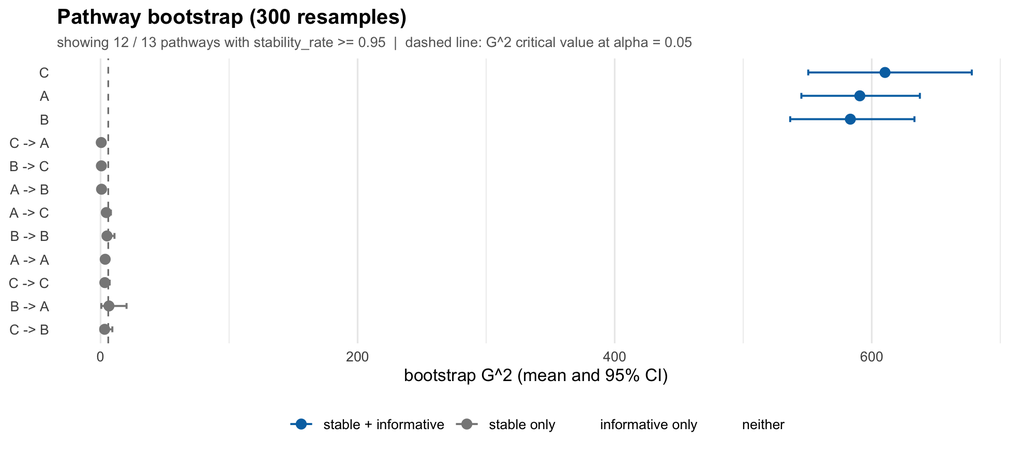

```r
plot(b_strong)
```

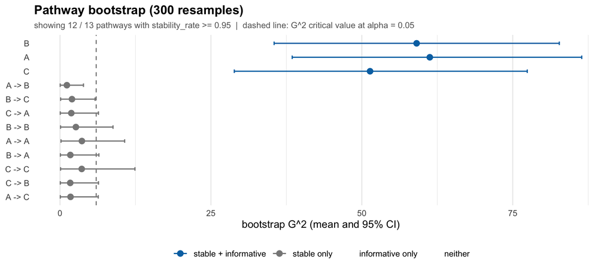

```r
plot(b_weak)
```

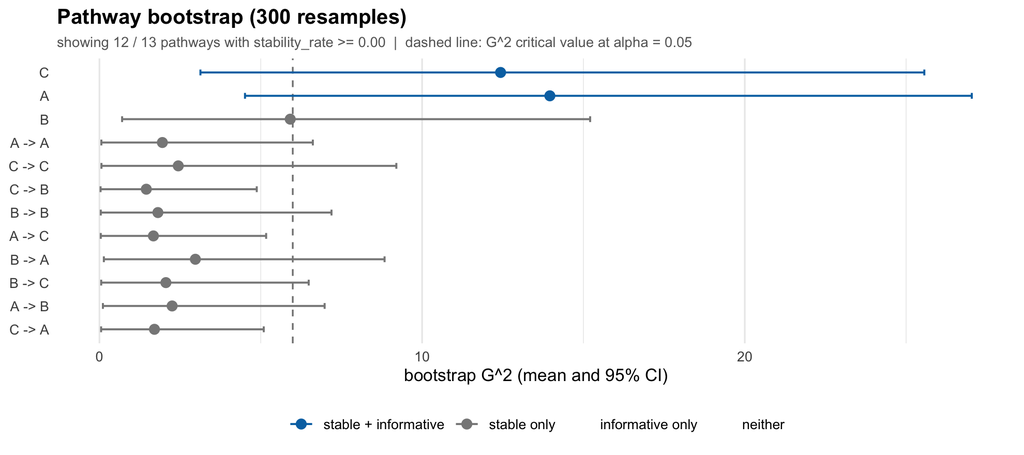

```r
plot(b_random, min_stability = 0)
```

The dashed line marks the chi-square critical value. STRONG’s depth-1 pathways sit far to the right of it; WEAK’s still clear it comfortably; RANDOM’s straddle or fall below it.

### Resample distributions of G²

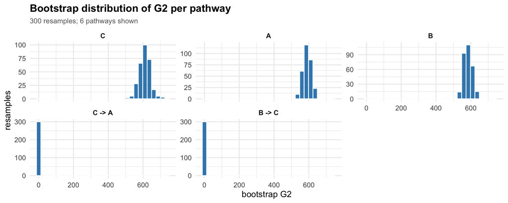

```r
plot_pathway_resamples(b_strong, stat = "G2", top = 6L)
```

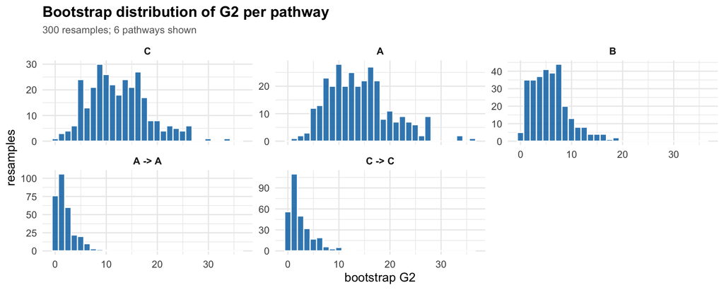

```r
plot_pathway_resamples(b_random, stat = "G2", top = 6L)
```

## Real data: `trajectories`

```r
data(trajectories)
dim(trajectories)
```

```
## [1] 138  15
```

```r
tree <- context_tree(trajectories, max_depth = 3L, min_count = 5L)
boot <- bootstrap_pathways(tree, iter = 500L, seed = 1L)
boot
```

```
## <transitiontrees_bootstrap>  500 resamples
##   stability  : count in [0.50, 1.50] x observed, p < 0.05
##   informative: G^2 > qchisq(0.95, df=k-1) = 5.99, threshold 0.80
##   pathways   : 38 total, 29 stable, 12 informative, 12 both
##
## top pathways (stable + informative first):
##                       pathway depth count p_stability stability_rate stable
##                       Average     1   751       0.002          1.000   TRUE
##                        Active     1   658       0.002          1.000   TRUE
##              Active -> Active     2   433       0.002          1.000   TRUE
##                    Disengaged     1   325       0.002          1.000   TRUE
##             Active -> Average     2   160       0.002          1.000   TRUE
##             Average -> Active     2   144       0.002          1.000   TRUE
##         Disengaged -> Average     2   122       0.002          1.000   TRUE
##  Active -> Average -> Average     3    80       0.002          1.000   TRUE
##   Average -> Active -> Active     3    70       0.002          1.000   TRUE
##      Disengaged -> Disengaged     2   139       0.010          0.992   TRUE
##  informative_rate informative mean_G2 ci_G2_lo ci_G2_hi
##             1.000        TRUE 119.906   75.898  171.678
##             1.000        TRUE 320.335  253.141  395.531
##             0.992        TRUE  18.063    7.715   29.959
##             1.000        TRUE 181.365  111.871  262.649
##             0.996        TRUE  28.781   12.718   48.649
##             1.000        TRUE  30.522   12.497   52.917
##             1.000        TRUE  32.303   13.445   53.598
##             0.864        TRUE  13.121    2.705   26.414
##             0.994        TRUE  24.213    9.799   43.740
##             0.996        TRUE  21.624    9.183   37.531
## # ... 28 more pathways (use summary(x) for full table)
```

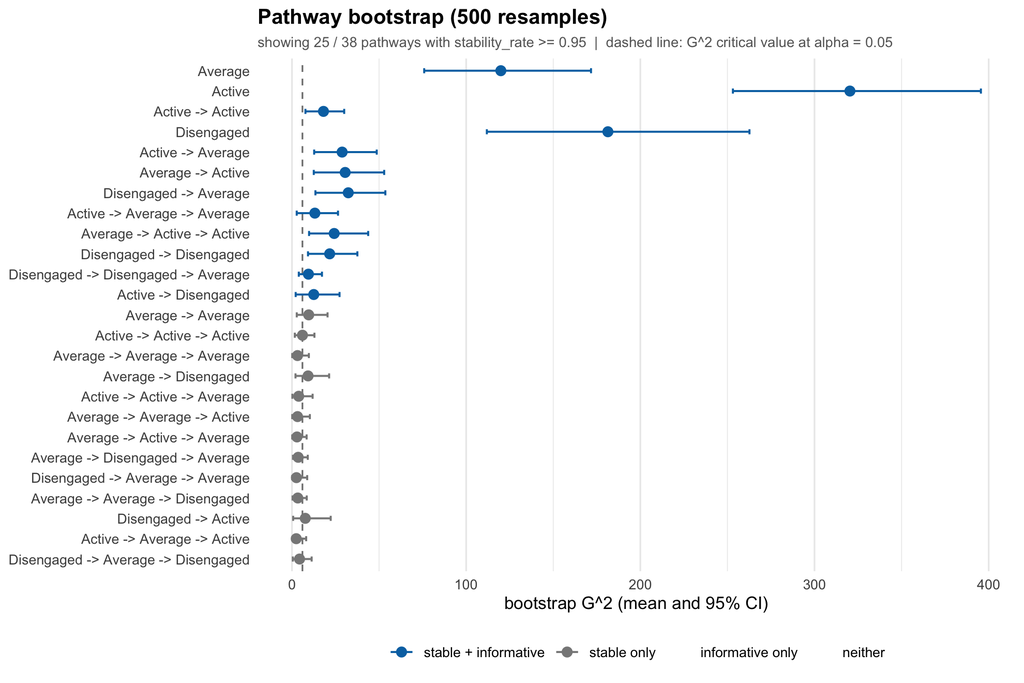

```r
plot(boot)
```

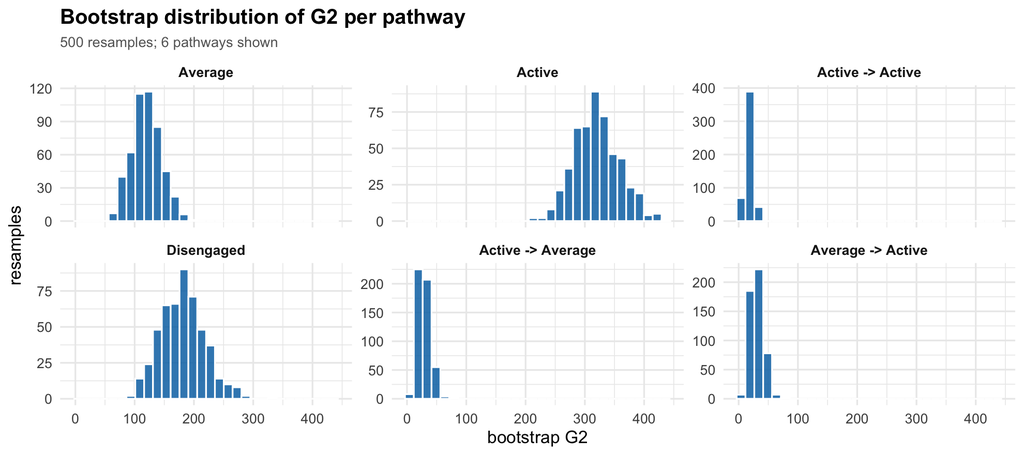

```r
plot_pathway_resamples(boot, stat = "G2", top = 6L)
```

```r
summary(boot)
```

| pathway | depth | count | likely_next | next_probability | divergence | changes_prediction | G2 | p_stability | stability_rate | stable | informative_rate | informative | flip_consistency | mean_count | sd_count | ci_count_lo | ci_count_hi | mean_next_probability | sd_next_probability | ci_next_probability_lo | ci_next_probability_hi | mean_divergence | sd_divergence | ci_divergence_lo | ci_divergence_hi | mean_G2 | sd_G2 | ci_G2_lo | ci_G2_hi |
| --- | --- | --- | --- | --- | --- | --- | --- | --- | --- | --- | --- | --- | --- | --- | --- | --- | --- | --- | --- | --- | --- | --- | --- | --- | --- | --- | --- | --- | --- |
| Average | 1 | 751 | Average | 0.6098535 | 0.113562458 | FALSE | 118.2306773 | 0.001996008 | 1.000 | TRUE | 1.000 | TRUE | 0.8760000 | 749.672 | 47.416041 | 653.475 | 838.575 | 0.6079221 | 0.02393634 | 0.5576430 | 0.6547803 | 0.116119772 | 0.026314176 | 0.0713062660 | 0.17282800 | 119.906430 | 24.506867 | 75.89801405 | 171.678420 |
| Active | 1 | 658 | Active | 0.6975684 | 0.349487162 | TRUE | 318.7957903 | 0.001996008 | 1.000 | TRUE | 1.000 | TRUE | 0.8760000 | 659.914 | 54.584958 | 551.000 | 769.000 | 0.6981870 | 0.02707862 | 0.6444943 | 0.7529293 | 0.352459940 | 0.050533628 | 0.2596493874 | 0.44918203 | 320.335376 | 38.129568 | 253.14087502 | 395.530787 |
| Active -> Active | 2 | 433 | Active | 0.7852194 | 0.028601567 | FALSE | 17.1685328 | 0.001996008 | 1.000 | TRUE | 0.992 | TRUE | 1.0000000 | 435.168 | 48.019199 | 342.475 | 532.625 | 0.7848138 | 0.02756547 | 0.7255984 | 0.8308172 | 0.030204916 | 0.010187385 | 0.0132148882 | 0.05218554 | 18.062771 | 5.837466 | 7.71485030 | 29.959469 |
| Disengaged | 1 | 325 | Disengaged | 0.4830769 | 0.403065556 | TRUE | 181.5994399 | 0.001996008 | 1.000 | TRUE | 1.000 | TRUE | 0.8240000 | 325.392 | 33.924328 | 261.900 | 396.525 | 0.4863621 | 0.03506343 | 0.4315050 | 0.5615301 | 0.402645453 | 0.075342567 | 0.2671229148 | 0.56494056 | 181.364753 | 37.389352 | 111.87118154 | 262.648539 |
| Active -> Average | 2 | 160 | Average | 0.5187500 | 0.122825881 | FALSE | 27.2436522 | 0.001996008 | 1.000 | TRUE | 0.996 | TRUE | 0.9540000 | 159.314 | 13.993249 | 133.000 | 188.000 | 0.5216073 | 0.03952184 | 0.4517398 | 0.6040268 | 0.131229099 | 0.047611531 | 0.0539814755 | 0.23217196 | 28.780654 | 10.134027 | 12.71752070 | 48.648969 |
| Average -> Active | 2 | 144 | Active | 0.5000000 | 0.147275598 | FALSE | 29.4000956 | 0.001996008 | 1.000 | TRUE | 1.000 | TRUE | 0.6540000 | 143.702 | 14.047201 | 115.000 | 172.525 | 0.5241698 | 0.02642612 | 0.4883721 | 0.5833333 | 0.155215092 | 0.058528425 | 0.0601742959 | 0.27791884 | 30.522394 | 10.794549 | 12.49721887 | 52.916791 |
| Disengaged -> Average | 2 | 122 | Average | 0.5163934 | 0.176186405 | FALSE | 29.7980388 | 0.001996008 | 1.000 | TRUE | 1.000 | TRUE | 0.9380000 | 122.946 | 13.169128 | 96.000 | 150.000 | 0.5155576 | 0.04189521 | 0.4469660 | 0.6049369 | 0.191381637 | 0.063719227 | 0.0828630006 | 0.32849738 | 32.303091 | 10.203020 | 13.44472072 | 53.597688 |
| Active -> Average -> Average | 3 | 80 | Average | 0.5750000 | 0.101876320 | FALSE | 11.2984454 | 0.001996008 | 1.000 | TRUE | 0.864 | TRUE | 0.9920000 | 79.880 | 8.738554 | 62.475 | 97.000 | 0.5755364 | 0.06485768 | 0.4528333 | 0.6928462 | 0.119133473 | 0.059872093 | 0.0263097668 | 0.24778967 | 13.120680 | 6.503994 | 2.70492588 | 26.414085 |
| Average -> Active -> Active | 3 | 70 | Active | 0.5285714 | 0.233006163 | FALSE | 22.6110591 | 0.001996008 | 1.000 | TRUE | 0.994 | TRUE | 0.8360000 | 70.190 | 8.635221 | 54.000 | 87.000 | 0.5369016 | 0.04374072 | 0.4715094 | 0.6275904 | 0.252859930 | 0.098735011 | 0.0966232300 | 0.47984809 | 24.213337 | 8.763871 | 9.79914362 | 43.739639 |
| Disengaged -> Disengaged | 2 | 139 | Disengaged | 0.6762590 | 0.109773627 | FALSE | 21.1528199 | 0.009980040 | 0.992 | TRUE | 0.996 | TRUE | 0.8200000 | 138.772 | 25.957573 | 91.000 | 190.525 | 0.6695795 | 0.04210683 | 0.5815626 | 0.7418340 | 0.116592076 | 0.047195185 | 0.0474821550 | 0.22672448 | 21.624054 | 7.464231 | 9.18314052 | 37.530587 |

[output cut: 28 more lines]

## Design notes

- **Bootstrap operates on raw counts.** No `nmin` filter, no smoothing inside the loop, no extra parameters. Pathways tracked are exactly the ones in the original tree; their values come from per-depth count aggregation.
- **`stable` answers “does the value reproduce?”** — the edge-level bootstrap framing. With enough data, counts reproduce regardless of whether the underlying structure is informative.
- **`informative` answers “does the LR test reproducibly clear the threshold?”** — the bootstrap analogue of `prune(criterion = "G2")`. This is the test that distinguishes real signal from finite-sample noise.
- **Use both flags together.** A pathway worth interpreting is one where `stable AND informative`. The summary sorts those first.
- **No `prune()` inside the resample loop.** Pruning is a downstream filter on the bootstrap output, not part of the fit replay.
- **Performance.** Per-sequence `(context, next_state)` pair-index vectors are precomputed once per depth (a transition fast-path). Bootstrap iterations are one `unlist`+`tabulate` per depth followed by per-pathway count lookups, with no `data.frame` construction inside the loop.